# Satellite data

## What are they?

In the following,

```r
# install.packages("starsdata", repos = "http://pebesma.staff.ifgi.de", type = "source")
library(stars)
granule = system.file("sentinel/S2A_MSIL1C_20180220T105051_N0206_R051_T32ULE_20180221T134037.zip",
    package = "starsdata")
s2 = paste0("SENTINEL2_L1C:/vsizip/", granule,
    "/S2A_MSIL1C_20180220T105051_N0206_R051_T32ULE_20180221T134037.SAFE/MTD_MSIL1C.xml:10m:EPSG_32632")
(p = read_stars(s2, proxy = TRUE))
```

```
## stars_proxy object with 1 attribute in file:
## $`MTD_MSIL1C.xml:10m:EPSG_32632`
## [1] "SENTINEL2_L1C:/vsizip//home/edzer/R/x86_64-pc-linux-gnu-library/3.6/starsdata/sentinel/S2A_MSIL1C_20180220T105051_N0206_R051_T32ULE_20180221T134037.zip/S2A_MSIL1C_20180220T105051_N0206_R051_T32ULE_20180221T134037.SAFE/MTD_MSIL1C.xml:10m:EPSG_32632"
##
## dimension(s):
##      from    to offset delta                       refsys point values
## x       1 10980  3e+05    10 +proj=utm +zone=32 +datum...    NA   NULL [x]
## y       1 10980  6e+06   -10 +proj=utm +zone=32 +datum...    NA   NULL [y]
## band    1     4     NA    NA                           NA    NA   NULL
```

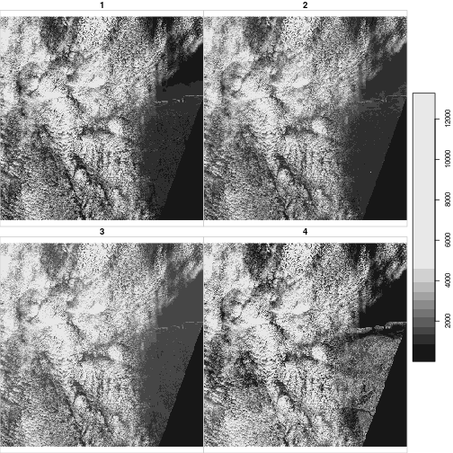

```r
plot(p)
```

we see a large triangle being black. These are zero values, (wrongly!) not encoded as NODATA (or NA). Specifying them blanks them out:

```r
(p = read_stars(s2, proxy = TRUE, NA_value = 0))
```

```
## stars_proxy object with 1 attribute in file:
## $`MTD_MSIL1C.xml:10m:EPSG_32632`
## [1] "SENTINEL2_L1C:/vsizip//home/edzer/R/x86_64-pc-linux-gnu-library/3.6/starsdata/sentinel/S2A_MSIL1C_20180220T105051_N0206_R051_T32ULE_20180221T134037.zip/S2A_MSIL1C_20180220T105051_N0206_R051_T32ULE_20180221T134037.SAFE/MTD_MSIL1C.xml:10m:EPSG_32632"
##
## NA_value:  0
## dimension(s):
##      from    to offset delta                       refsys point values
## x       1 10980  3e+05    10 +proj=utm +zone=32 +datum...    NA   NULL [x]
## y       1 10980  6e+06   -10 +proj=utm +zone=32 +datum...    NA   NULL [y]
## band    1     4     NA    NA                           NA    NA   NULL
```

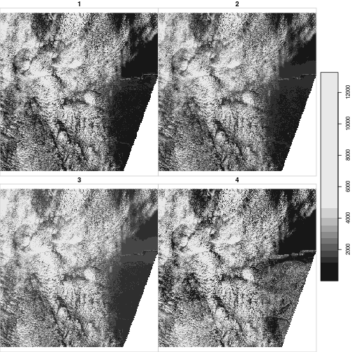

```r
plot(p)
```

```r
if (!file.exists("tiles.rda")) {
        # read tile geometries from:
        # https://sentinel.esa.int/web/sentinel/missions/sentinel-2/data-products
        tiles = read_sf("https://sentinel.esa.int/documents/247904/1955685/S2A_OPER_GIP_TILPAR_MPC__20151209T095117_V20150622T000000_21000101T000000_B00.kml")
        tiles = st_zm(st_collection_extract(tiles, "POLYGON"))
        tiles$Description = NULL
        tiles = aggregate(tiles, list(Name = tiles$Name), function(x) x[1])
        save(tiles, file = "tiles.rda")
} else
        load("tiles.rda")

DE = st_as_sf(raster::getData("GADM", country = "DE", level = 1))
# select scenes:

tiles = tiles[DE,]
```

```
## although coordinates are longitude/latitude, st_intersects assumes that they are planar
```

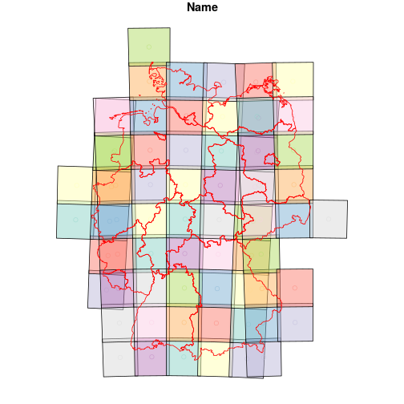

```r
plot(tiles[,1], reset = FALSE, col = sf.colors(categorical=TRUE, alpha=.5))
plot(DE, add = TRUE, col = NA, border = 'red')
```

(Note that the tiles have 10 km overlap, everywhere)

In the case of Sentinel2, for each of these tiles we get an image roughly every 5 days. Each image is roughly 1 Gb, and contains [13 bands](https://en.wikipedia.org/wiki/Sentinel-2):

- 4 at 10 m resolution,
- 6 at 20 m resolution,
- 3 at 60 m resolution.

Why not exactly 5 days?

- satellites follow an orbit, and have some revisit time, but not exactly a multiple of days (I think)
- the orbit is sun synchronous, since reflected sunlight is measured
- since swath width is constant, close to the poles we get more overlapping swaths than close to the equator, and hence more frequent observations

For combining tiles that do not line up (mosaic, warp) into a regular raster, package [gdalcubes](https://cran.r-project.org/web/packages/gdalcubes/index.html) can be used.

## Data cubes

See also [this](https://keen-swartz-3146c4.netlify.com/raster.html) chapter.

Data cubes are data structures where values are arranged at the junction of two (one) or more *independent dimensions*. These dimensions can reflect (discretized version) of continuous variables (e.g. three space dimension, one time dimensions), but also reflect discrete variables (e.g. species, variable measured or modelled in a weather model).

Vector data (points, lines, polygons) can be encoded along a single dimension, as an enumerated set of geographical locations, linestrings, or polygons.

Examples include:

- a simple table (1-dimensional (contrived): sequence of features -> properties)
- a raster image (2-dimensional: x, y -> cell value)
- time series for a set of stations (2-dimensional: location, time -> measurement)
- satellite image (3-dimensional: x, y, color -> pixel value)
- sequence of satellite images (4-dimensional: x, y, t, color -> pixel value)
- weather or climate data (5-dimensional: x, y, z, t, attribute -> value)

Data cubes can be sparse or dense: if they are dense, every combination of dimension values has an actual value (in the database, or the memory object); if they are sparse, only combinations for which there is a data value are stored. Systems for sparse data cubes are relatively rare, an example is [SciDB](https://www.paradigm4.com/try_scidb/).

The stars R package implements dense **vector and raster data cubes**. See the data model vignette (article) for an explanation of the different forms it accepts.

Satellite imagery like Sentinel2 can be seen as sparse data cubes: since the satellites follow a path, a particular observed tile has its own time stamp, and all other tiles will be empty for that time stamp. Also, collections of tiles over different UTM systems do not form a (single) regular grid in x and y.

Nevertheless, it is often easier to (be able to) treat the data as if it were a data cube. We can do this by a *data cube view*: for a particular x/y grid (in a particular coordinate reference system) and a sequence of time steps (e.g. monthly) we *consider* (in some way, by resampling) the underlying imagery, and visualise it or build models for it. This approach is taken by [Google Earth Engine](https://earthengine.google.com/), and is also followed by the [openEO API](http://openeo.org/). The stars R package follows this design pattern but in a much simplified (pure R) approach.

Key features of this approach:

- keep the data in its original form, but give the user a view resample to a given (dense) data cube; allow arbitrary data cube views
- don't mozaic to a common space/time grid before analysing, but do this on the fly
- for interactive use: only read the pixels that are actually shown on screen; e.g. if North America is 25 M \(km^2\) and our viewport (screen) 1000 x 1000 pixels, one pixel (forget the seas) is roughly 25 \(km^2\), meaning we *look at data* on a 5 km grid spacing. This means, for 10 m resolution data, we *read* one pixel from every 500 rows and colums. This means we (can) discard 99.9996\% of the data.
- for showing model results, we can (potentially) run the model at the lower resolution (e.g. pixel time series model, or band index such as NDVI)
- we can develop our model interactively, and switch to batch processing when done with model development
- no need to download the data, as they are in the cloud

See the stars proxy vignette for examples of this pattern; the images above only read and show the pixels present in the html / on screen.

For larger areas and time periods, downloading satellite data to a local storage is a lost game; even if local storage is sufficient, network bandwidth is likely to be the limiting factor.

## This is all about handling, what about modelling?

In terms of spatial statistics, remote sensing data analysis is used e.g.

- to identify features, e.g. forest fires or ice bergs, and use point pattern analysis to model their spatial or spatiotemporal properties (point pattern analysis)
- to fill gaps, mostly caused by clouds; this is a spatio-temporal interpolation problem (geostatistics)
- to model relationships between variables, potentially considering the RS image as a lattice variable, modelling and accounting for spatial correlation (lattice data)

Otherwise, typical RS analysis challenges involve

- from continuous to continuous: identify indexes based on multiple bands that express a certain property better than the individual bands (e.g., NDVI for greenness / vegetation abundance)
- from continuous to discrete: identify land use categories pixel-wise, identify regions of the same type (segmentation), segmenting time series (when did a certain change, e.g. deforestation, happen?)